# Modelo Lineal

# Clase 4: Modelos lineales

[figure not shown]

Los modelos lineales son un tipo de modelo estadístico utilizado para predecir el valor de una variable de interés (la variable dependiente) a partir de uno o más variables predictivas (las variables independientes). Los modelos lineales se basan en la suposición de que la relación entre la variable dependiente y las variables independientes es lineal.

Para mayor referencia sobre el enfoque metodológico de esta clase, se recomienda consultar la siguiente lectura:

[A large-scale assessment of eastern whip-poor-will](https://doi.org/10.1016/j.jenvman.2024.121786)

[The effects of agricultural landscape composition and heterogeneity on bird diversity and community structure](https://doi.org/10.1016/j.gecco.2020.e01191)

### Contenido

#### Informacion de los datos

Para esta clase utilizaremos la base de datos creeps.txt. Observe que este archivo se encuentra en formato .txt.

Esta base de datos proviene de la investigación doctoral del Dr. McGarigal, realizada en el noroeste del Pacífico de Estados Unidos [paper](https://doi.org/10.2307/2937059).

```r
creeps <- read.table("data/creeps.txt", header = T)
```

Procedamos a visualizar nuestra base de datos.

```r
head(creeps)
```

```
##        abund elevation road.dens stream.den mps.CS mps.S contagion conifer
## 1 0.02857143       635        19         29  17.19 58.43     55.79   56.61
## 2 0.43750000       533         1         28  22.54 61.98     67.14   64.02
## 3 0.37837838       396        11         32  10.04 22.39     70.66   49.20
## 4 0.55882353       342        18         32  17.93 35.87     46.25   31.41
## 5 0.34285714       369        30         30  11.80 16.97     69.44   29.30
## 6 0.28125000       327        34         38  11.91 25.01     67.52    5.54
##     saw  pole sapling
## 1  0.71 93.61    0.00
## 2 80.15 19.85    0.00
## 3 43.44 49.18    0.00
## 4 57.23 30.75    0.00
## 5 24.46 33.24   27.15
## 6 39.89 28.69   17.40
```

- elevation: promedio de la elevacion a lo largo del sitio
- road.dens: desidad de caminos en el sitio
- stream.den: desnisdad que quebradas en el sitio
- mps.CS: promedio de tamano de parche, tomando en cuenta composision y estructura de vegetacion
- mps.S: : promedio de tamano de parche, tomando en cuenta estructura de vegetacion
- contagion: una medidad de conectividad general del mosaico de parches basados en mps.s
- conifer: porcentaje de paisage compuesto de bosque de coniferas
- saw: porcentaje de paisage compuesto de large sawtimber (late-seral)
- pole: porcentaje de paisage compuesto de pole timber (mid-seral)
- sapling: porcentaje de paisage compuesto de saplings (early-seral)

#### Correlacion simple y multiple

La correlación es una medida que describe la relación entre dos variables. Existen diferentes tipos de correlación, dependiendo del tipo de variables que se están analizando. Algunos de los tipos más comunes son:

- Correlación lineal: La correlación lineal mide la relación entre dos variables cuantitativas y se puede medir utilizando el coeficiente de correlación lineal (también conocido como el coeficiente de Pearson). Este coeficiente varía entre -1 y 1 y mide la intensidad y la dirección de la relación lineal entre las dos variables. Un valor de 1 indica una correlación perfectamente positiva, un valor de -1 indica una correlación perfectamente negativa y un valor de 0 indica ausencia de correlación.
- Correlación no lineal: La correlación no lineal mide la relación entre dos variables cuantitativas o cualitativas y no sigue una relación lineal. Algunas de las métricas que se pueden utilizar para medir la correlación no lineal son el coeficiente de correlación de Spearman y el coeficiente de correlación de Kendall.

**Correlacion de Pearson**

```r
cor.test(creeps$abund, creeps$saw)
```

```
##
##  Pearson's product-moment correlation
##
## data:  creeps$abund and creeps$saw
## t = 6.7047, df = 28, p-value = 2.809e-07
## alternative hypothesis: true correlation is not equal to 0
## 95 percent confidence interval:
##  0.5921819 0.8927700
## sample estimates:
##       cor
## 0.7849797
```

**Correlacion de Spearman**

```r
cor.test(creeps$abund, creeps$saw, method = "spearman")
```

```
##
##  Spearman's rank correlation rho
##
## data:  creeps$abund and creeps$saw
## S = 838.15, p-value = 4.62e-08
## alternative hypothesis: true rho is not equal to 0
## sample estimates:
##       rho
## 0.8135367
```

**Correlacion multile**

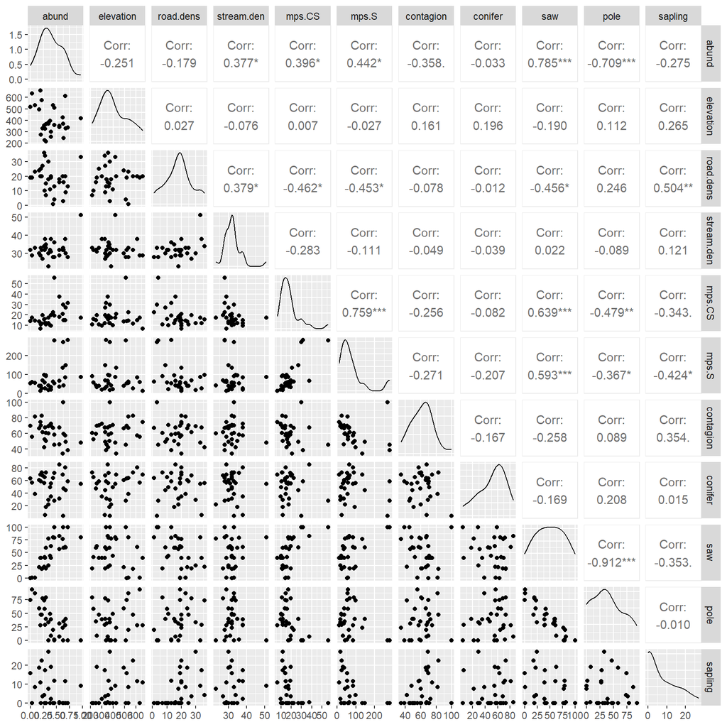

```r
library(ggplot2)
library(GGally)

MulplePlot <- ggpairs(creeps)
MulplePlot
```

#### Modelo lineal simple

Principal referencia utilizada: [GLMs in R for Ecology 2nd edition](https://www.amazon.com/-/es/GLMs-Ecology-Prof-Carl-Smith/dp/B0CCZWCTW1)

Un modelo lineal simple es un modelo matemático que se utiliza para predecir una variable dependiente (también conocida como la variable objetivo o la variable respuesta) a partir de una única variable independiente (también conocida como la variable predictor o la variable explicativa). Este tipo de modelo se basa en la hipótesis de que la relación entre la variable dependiente y la variable independiente es lineal, es decir, que puede ser representada por una línea recta en un gráfico.

La forma general de un modelo lineal simple es:

$$y = \beta_0 + β1 * x +
\epsilon_i$$

donde:

- $y$ variable respuesta (dependiente)
- $x$ variable explicativa (predictora)
- $\beta_0$ es el intercepto (el valor de $y$ cuando $x$ es igual a cero)
- $\beta_1$ pendiente (cambio esperado en $y$ por cada unidad de $x$)
- $\epsilon_i$ error aleatorio del modelo para la observación $i$

**Ejemplo modelo lineal simple**

Para realizar nuetro ejemplo utilizaremos la variable `conifer` para predecir nuestra variable respuesta `abund`

```r
fit1 <- lm(abund ~ conifer, data= creeps)
```

Para visualizar nuestro resultado podemos utilizar el comando `summary()`

```r
summary(fit1)
```

```
##
## Call:
## lm(formula = abund ~ conifer, data = creeps)
##
## Residuals:
##      Min       1Q   Median       3Q      Max
## -0.38821 -0.14525 -0.03574  0.17354  0.57945
##
## Coefficients:
##               Estimate Std. Error t value Pr(>|t|)
## (Intercept)  0.4097130  0.1095886   3.739 0.000843 ***
## conifer     -0.0003403  0.0019764  -0.172 0.864533
## ---
## Signif. codes:  0 '***' 0.001 '**' 0.01 '*' 0.05 '.' 0.1 ' ' 1
##
## Residual standard error: 0.2279 on 28 degrees of freedom
## Multiple R-squared:  0.001058,   Adjusted R-squared:  -0.03462
## F-statistic: 0.02965 on 1 and 28 DF,  p-value: 0.8645
```

`NOTA`: Un modelo lineal puede dar un valor de R cuadrado negativo cuando el modelo es peor que una línea horizontal en la predicción de la variable dependiente (también conocida como la variable objetivo o la variable respuesta). Esto significa que el modelo no es capaz de explicar ninguna de la variabilidad de la variable dependiente.

**Estudio de caso**

La Universidad de Massachusetts Amherst ha contratado a un asistente de investigación con el objetivo de apoyar al Dr. McGarigal en la comprensión de las variables del paisaje que influyen en la abundancia de Certhia americana. Para ello, el Dr. McGarigal ha recopilado datos en campo y ha organizado una base de datos que permite analizar la relación entre la estructura del paisaje y la distribución de la especie. Las variables incluidas en el análisis son: elevation, que representa la elevación promedio del sitio; road.dens, la densidad de caminos; stream.den, la densidad de quebradas; mps.CS, el tamaño promedio de parche considerando la composición y estructura de la vegetación; mps.S, el tamaño promedio de parche basado únicamente en la estructura de la vegetación; contagion, una medida de conectividad general del mosaico de parches basada en mps.S; conifer, el porcentaje del paisaje compuesto por bosque de coníferas; saw, el porcentaje de bosque en etapa tardía (large sawtimber); pole, el porcentaje de bosque en etapa intermedia (pole timber); y sapling, el porcentaje del paisaje compuesto por bosques en etapa temprana (saplings).

Asumiendo que hemos comprendido la organización de la base de datos y realizado una exploración inicial de los datos, el primer paso consiste en ajustar un modelo lineal múltiple que incluya todas las variables predictoras de interés. A este modelo, que contiene todas las variables explicativas, lo llamaremos Modelo_completo.

```r
Modelo_completo <- lm(abund ~ conifer +
                        elevation +
                        road.dens +
                        stream.den +
                        mps.CS +
                        mps.S +
                        contagion +
                        saw +
                        pole +
                        sapling, data= creeps)
```

El siguiente paso consiste en verificar que las variables predictoras no presenten correlación entre ellas, es decir, evaluar la posible presencia de colinealidad. Este es un paso fundamental en el análisis, ya que la colinealidad entre variables explicativas puede inflar la varianza de los estimadores, generar inestabilidad en los coeficientes del modelo y dificultar la interpretación de los efectos individuales de cada variable.

Para determinar la colinealidad entre las variables predictoras, podemos utilizar el Factor de Inflación de la Varianza (VIF, por sus siglas en inglés). El VIF cuantifica cuánto se incrementa la varianza de los coeficientes del modelo debido a la correlación entre predictores, permitiendo así identificar variables altamente colineales.

Este diagnóstico puede realizarse en R utilizando la función vif() del paquete car o mediante el paquete performance, el cual ofrece una evaluación más general de los supuestos del modelo, incluyendo la colinealidad.

```r
car::vif(Modelo_completo)
```

```
##    conifer  elevation  road.dens stream.den     mps.CS      mps.S  contagion
##   1.347365   1.241031   2.606967   1.440849   3.267840   3.998738   1.745666
##        saw       pole    sapling
##  59.503682  43.469702   5.555638
```

```r
performance::check_collinearity(Modelo_completo)
```

```
## # Check for Multicollinearity
##
## Low Correlation
##
##        Term  VIF     VIF 95% CI adj. VIF Tolerance Tolerance 95% CI
##     conifer 1.35 [ 1.13,  1.94]     1.16      0.74     [0.51, 0.89]
##   elevation 1.24 [ 1.07,  1.85]     1.11      0.81     [0.54, 0.94]
##   road.dens 2.61 [ 1.94,  3.75]     1.61      0.38     [0.27, 0.52]
##  stream.den 1.44 [ 1.18,  2.06]     1.20      0.69     [0.49, 0.84]
##      mps.CS 3.27 [ 2.38,  4.74]     1.81      0.31     [0.21, 0.42]
##       mps.S 4.00 [ 2.86,  5.84]     2.00      0.25     [0.17, 0.35]
##   contagion 1.75 [ 1.38,  2.48]     1.32      0.57     [0.40, 0.73]
##
## Moderate Correlation
##
##     Term  VIF     VIF 95% CI adj. VIF Tolerance Tolerance 95% CI
##  sapling 5.56 [ 3.89,  8.18]     2.36      0.18     [0.12, 0.26]
##
## High Correlation
##
##  Term   VIF     VIF 95% CI adj. VIF Tolerance Tolerance 95% CI
##   saw 59.50 [39.70, 89.43]     7.71      0.02     [0.01, 0.03]
##  pole 43.47 [29.06, 65.28]     6.59      0.02     [0.02, 0.03]
```

En este caso, ambas formas de evaluar la colinealidad indican que las variables saw y pole están inflando el modelo debido a su alta correlación con otras variables predictoras. Por lo tanto, el primer paso consiste en eliminar la variable con el valor de VIF más alto; en este caso, saw (VIF = 59.50).

Posteriormente, se ajusta nuevamente el modelo y se vuelve a evaluar la colinealidad. Este proceso se repite de manera secuencial, eliminando en cada paso la variable con el VIF más elevado, hasta que todas las variables del modelo presenten valores de VIF inferiores a 3, lo que indica niveles aceptables de colinealidad.

```r
Modelo_Final <- lm(abund ~ conifer +
                        elevation +
                        road.dens +
                        stream.den +
                        mps.S +
                        contagion +
                        pole +
                        sapling, data= creeps,
                   na.action = na.fail)
```

Una vez identificadas las variables que no presentan colinealidad, se procede a evaluar cuál es el mejor conjunto de covariables que explica la abundancia de la especie. Para ello, podemos utilizar el paquete MuMIn, cuya función dredge genera todas las combinaciones posibles de las variables predictoras. En este caso específico, al contar con 8 covariables, el número total de modelos candidatos es $2^8 = 256$, a los cuales se les suma el modelo nulo.

El modelo nulo es un modelo que no incluye variables explicativas (solo el intercepto) y representa la hipótesis de que la variación en la abundancia puede explicarse únicamente por el azar o por un valor promedio constante. Este modelo se utiliza como referencia para comparar el desempeño de los modelos que sí incluyen covariables, permitiendo evaluar cuánto mejora la capacidad explicativa al incorporar información del paisaje frente a un escenario sin predictores.

#### Seleccion de modelo usando AIC

Recomendacion: [A practical guide to selecting models for exploration, inference, and prediction in ecology](https://doi.org/10.1002/ecy.3336)

La selección del modelo más adecuado para un conjunto de datos es un proceso importante en el análisis de datos. Existen diferentes criterios que se pueden utilizar para seleccionar el modelo más adecuado, dependiendo del objetivo del análisis y del tipo de datos que se tienen. Algunos de los criterios más comunes son:

- Simplicidad: Un modelo más simple es más fácil de interpretar y generalizar, pero puede no ser tan preciso como un modelo más complejo.
- Precisión: Un modelo más preciso es capaz de explicar mejor la variabilidad de la variable dependiente. Se pueden utilizar métricas como el coeficiente de determinación (R cuadrado) o el error cuadrático medio (MSE) para evaluar la precisión de un modelo.
- Bondad de ajuste: Un modelo con una bondad de ajuste adecuada se ajusta bien a los datos, pero también tiene capacidad de generalización a datos futuros. Se pueden utilizar métricas como el AIC o el BIC para evaluar la bondad de ajuste de un modelo.
- Interpretabilidad: Un modelo más fácil de interpretar es más útil para comprender las relaciones entre las variables y para hacer predicciones basadas en ellas.

El AIC (Information Criterion) es una métrica que se utiliza para evaluar la bondad de ajuste de diferentes modelos de regresión y seleccionar el modelo más adecuado. El AIC se basa en la idea de que un modelo más preciso debe tener un menor AIC, pero también debe tener una suficiente capacidad de generalización a datos futuros.

La fórmula del AIC es:

$$AIC = 2 * k - 2 * ln(L)$$

donde:

- k es el número de parámetros del modelo
- ln(L) es el logaritmo natural del valor de verosimilitud del modelo

A continuacion utilizares el Criterio de Informacion de Akaike (AIC) para identificar el modelo mas adeacuado

```r
library(MuMIn)

Modelos_seleccion <- MuMIn::dredge(Modelo_Final)
```

```
## Fixed term is "(Intercept)"
```

```r
head(data.frame(Modelos_seleccion))
```

```
##     X.Intercept.     conifer    contagion elevation        mps.S         pole
## 211   0.31286643          NA -0.003020177        NA           NA -0.005209402
## 209   0.11922975          NA           NA        NA           NA -0.005337109
## 210   0.05151703 0.001394664           NA        NA           NA -0.005552182
## 217   0.04073368          NA           NA        NA 0.0004218322 -0.004920789
## 212   0.24014614 0.001036191 -0.002670616        NA           NA -0.005383975
## 219   0.23575316          NA -0.002821258        NA 0.0003458646 -0.004876467
##     road.dens      sapling stream.den df   logLik      AICc    delta     weight
## 211        NA -0.006988210 0.01556967  6 22.89236 -30.13255 0.000000 0.12980481
## 209        NA -0.008908940 0.01632114  5 21.18107 -29.86215 0.270400 0.11338985
## 210        NA -0.008980760 0.01646280  6 22.07388 -28.49559 1.636957 0.05725720
## 217        NA -0.007309228 0.01692262  6 21.87056 -28.08895 2.043599 0.04672280
## 212        NA -0.007263879 0.01576190  7 23.41329 -27.73567 2.396875 0.03915760
## 219        NA -0.005803095 0.01611233  7 23.40078 -27.71066 2.421892 0.03867084
```

En la tabla resultante se presentan los valores de AICc y ΔAICc (delta) para cada modelo candidato. El criterio de selección se basa principalmente en el valor de ΔAICc, el cual representa la diferencia entre el AICc de cada modelo y el modelo con el menor AICc (modelo “top 1”). Por esta razón, el mejor modelo siempre tendrá un ΔAICc = 0, mientras que los modelos restantes presentarán valores progresivamente mayores a medida que se alejan del mejor ajuste.

El AICc (Akaike Information Criterion corregido) es una medida que evalúa el equilibrio entre la calidad del ajuste del modelo y su complejidad, penalizando la inclusión de un número elevado de parámetros para evitar el sobreajuste, especialmente en muestras pequeñas. En este sentido, valores más bajos de AICc indican modelos con mejor balance entre ajuste y parsimonia.

A partir de ΔAICc se puede realizar la selección de modelos. Un criterio ampliamente utilizado es considerar todos aquellos modelos con ΔAICc < 2, ya que se asume que estos modelos tienen un soporte estadístico similar al del mejor modelo y, por lo tanto, no pueden ser descartados con suficiente evidencia.

#### Validación del modelo

Los modelos lineales se basan en una serie de supuestos sobre la distribución de los datos y la relación entre la variable respuesta y las variables predictoras. Estos supuestos son fundamentales para garantizar la validez de las inferencias estadísticas:

Linealidad: se asume que existe una relación lineal entre la variable dependiente y las variables independientes, es decir, que los cambios en la respuesta son proporcionales a los cambios en los predictores.

Homoscedasticidad: la varianza de los errores se mantiene constante a lo largo de todos los valores de las variables independientes.

Independencia de los errores: los residuos (diferencias entre los valores observados y los valores predichos) son independientes entre sí.

Normalidad de los errores: los residuos del modelo siguen una distribución aproximadamente normal.

El incumplimiento de estos supuestos puede afectar la precisión, estabilidad e interpretación de los resultados del modelo. Por esta razón, es esencial verificarlos antes de realizar inferencias o interpretar los coeficientes del modelo.

En este caso específico, el modelo se ajusta utilizando el conjunto de variables seleccionadas mediante el proceso de dredge, es decir, aquellas que presentan el mejor equilibrio entre ajuste y complejidad, de acuerdo con los criterios de información (AICc).

```r
Modelo_Top1 <- lm(abund ~ contagion +
                        pole +
                        sapling +
                        stream.den,
                        data= creeps)
```

En R existen diferentes formas de evaluar los supuestos de un modelo lineal. Una de las más sencillas y utilizadas es mediante la función `plot()`, la cual genera automáticamente gráficos diagnósticos basados en los residuos del modelo.

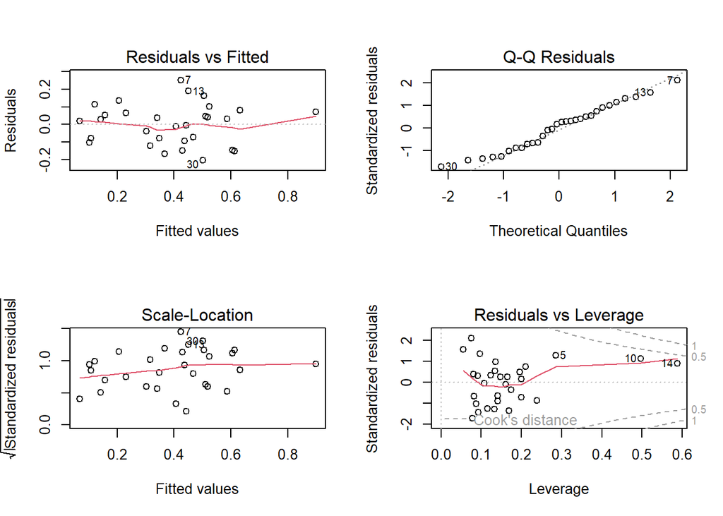

```r
par(mfrow = c(2,2))

plot(Modelo_Top1)
```

Sin embargo, los gráficos generados con el comando `plot()` pueden ser en cierta medida subjetivos, ya que su interpretación depende del criterio del analista. Por esta razón, en este curso utilizaremos el paquete DHARMa, el cual ofrece herramientas más robustas y estandarizadas para la validación de modelos, permitiendo evaluar de manera más formal el comportamiento de los residuos y los supuestos del modelo.

```r
library(DHARMa)
```

**Normalidad y homogeneidad de residuales**

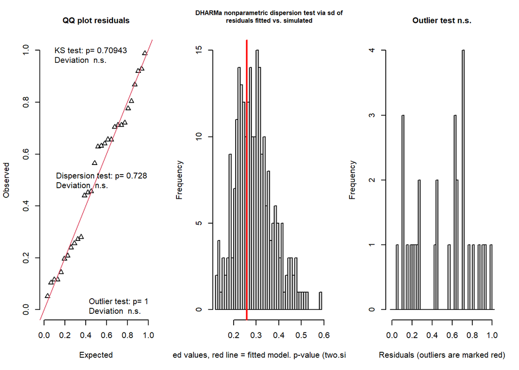

```
## $uniformity
##
##  Asymptotic one-sample Kolmogorov-Smirnov test
##
## data:  simulationOutput$scaledResiduals
## D = 0.128, p-value = 0.7094
## alternative hypothesis: two-sided
##
##
## $dispersion
##
##  DHARMa nonparametric dispersion test via sd of residuals fitted vs.
##  simulated
##
## data:  simulationOutput
## dispersion = 0.88105, p-value = 0.728
## alternative hypothesis: two.sided
##
##
## $outliers
##
##  DHARMa outlier test based on exact binomial test with approximate
##  expectations
##
## data:  simulationOutput
## outliers at both margin(s) = 0, observations = 30, p-value = 1
## alternative hypothesis: true probability of success is not equal to 0.007968127
## 95 percent confidence interval:
##  0.0000000 0.1157033
## sample estimates:
## frequency of outliers (expected: 0.00796812749003984 )
##                                                      0
```

```r
testResiduals(Modelo_Top1)
```

**colinealidad**

La colinealidad es un problema que puede surgir en el análisis de regresión cuando dos o más variables independientes están altamente correlacionadas entre sí. Esto puede ocurrir cuando las variables son muy similares o cuando son medidas de manera diferente pero representan el mismo concepto. La colinealidad puede dificultar la interpretación del modelo y afectar la precisión de las predicciones.

Para detectar la colinealidad en R, puede utilizar la función vif() del paquete car. Esta función calcula el factor de inflación de la varianza (VIF) para cada variable del modelo de regresión y permite evaluar la colinealidad entre ellas. El VIF de una variable mide cuánto aumenta la varianza de las estimaciones de los coeficientes debido a la colinealidad con otras variables. Valores altos de VIF indican colinealidad y valores bajos indican independencia.

```r
library(car)
vif(Modelo_Top1)
```

```
##  contagion       pole    sapling stream.den
##   1.163748   1.016340   1.169854   1.031420
```

#### Interpteracion Modelo Lineal

```r
summary(Modelo_Top1)
```

```
##
## Call:
## lm(formula = abund ~ contagion + pole + sapling + stream.den,
##     data = creeps)
##
## Residuals:
##      Min       1Q   Median       3Q      Max
## -0.20356 -0.09086  0.02342  0.06992  0.25081
##
## Coefficients:
##              Estimate Std. Error t value Pr(>|t|)
## (Intercept)  0.312866   0.194196   1.611  0.11972
## contagion   -0.003020   0.001738  -1.738  0.09449 .
## pole        -0.005209   0.000810  -6.431 9.82e-07 ***
## sapling     -0.006988   0.003037  -2.301  0.02999 *
## stream.den   0.015570   0.004765   3.268  0.00315 **
## ---
## Signif. codes:  0 '***' 0.001 '**' 0.01 '*' 0.05 '.' 0.1 ' ' 1
##
## Residual standard error: 0.1236 on 25 degrees of freedom
## Multiple R-squared:  0.7377, Adjusted R-squared:  0.6958
## F-statistic: 17.58 on 4 and 25 DF,  p-value: 5.54e-07
```

El modelo lineal indica que la abundancia de la especie (abund) está explicada por un conjunto de variables del paisaje, incluyendo contagion, pole, sapling y stream.den. El intercepto del modelo ($\beta_0$ = 0.3129) representa el valor esperado de la abundancia cuando todas las variables predictoras son iguales a cero.

En cuanto a las variables explicativas, contagion presenta un efecto negativo débil sobre la abundancia ($\beta$ = -0.0030), con una significancia marginal (t = -1.738, p = 0.094), lo que indica una tendencia, aunque no concluyente al nivel de $\alpha$ = 0.05. Por su parte, pole muestra un efecto negativo fuerte y altamente significativo ($\beta$ = -0.0052, t = -6.431, p < 0.001), indicando que un aumento en la proporción de bosque en etapa intermedia se asocia con una disminución en la abundancia. De manera similar, sapling también presenta un efecto negativo significativo ($\beta$ = -0.00699, t = -2.301, p = 0.030), sugiriendo que mayores proporciones de bosques en etapa temprana están asociadas con menor abundancia. En contraste, stream.den tiene un efecto positivo significativo ($\beta$ = 0.01557, t = 3.268, p = 0.003), indicando que una mayor densidad de quebradas está asociada con un incremento en la abundancia de la especie.

En conjunto, el modelo presenta un buen ajuste, explicando aproximadamente el 73.8% de la variabilidad en la abundancia ($R^2$ = 0.7377; $R^2$ ajustado = 0.6958). Esto indica que las variables del paisaje incluidas en el modelo tienen una alta capacidad explicativa sobre la variación observada. Adicionalmente, el modelo es globalmente significativo (F = 17.58, p < 0.001), lo que confirma que, en conjunto, las variables explicativas mejoran significativamente la predicción de la abundancia en comparación con un modelo nulo.

#### Grafico del modelo

Existen diversas formas de graficar un modelo lineal en R, como el uso de la función predict(), el paquete sjPlot o la función ggpredict() de distintos paquetes de visualización. En este caso, una alternativa recomendada es el uso del paquete ggeffects, el cual permite generar predicciones a partir del modelo de manera sencilla y consistente.

Para ello, se utiliza la función ggpredict(), que calcula las predicciones del modelo junto con sus intervalos de confianza. Posteriormente, estos resultados pueden visualizarse directamente con plot(). Además, los gráficos obtenidos pueden personalizarse y mejorarse utilizando funciones del paquete ggplot2, lo que permite generar figuras más flexibles y aptas para publicación.

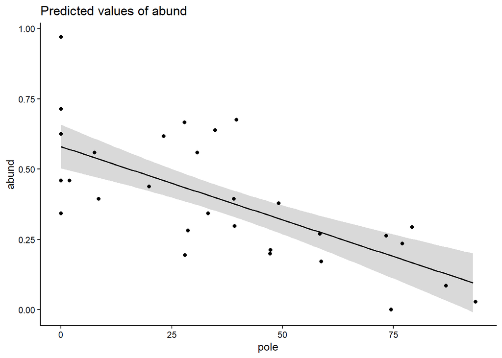

[figure not shown]

```r
library(ggeffects)
library(ggplot2)

Pre_pole <- ggpredict(Modelo_Top1, terms = "pole[n=100]")

plot(Pre_pole) +
  geom_point(data = creeps, aes(x= pole, y= abund))+
  theme_classic()
```